# Vnedor Log Analysis - Clutering Costomers Using Unsupervised Machine Learning

#### Group C

```python
df.loc[df.KM_pred == 2][['CustID', 'KM_pred']]
```

|  | CustID | KM_pred |
| --- | --- | --- |
| 1 | 198 | 2 |
| 2 | 260 | 2 |
| 15 | 1507 | 2 |
| 16 | 1563 | 2 |
| 17 | 1569 | 2 |
| 18 | 1585 | 2 |
| 19 | 1587 | 2 |
| 20 | 1596 | 2 |
| 21 | 1603 | 2 |
| 22 | 1628 | 2 |
| 24 | 1653 | 2 |
| 26 | 1655 | 2 |
| 27 | 1661 | 2 |
| 29 | 1692 | 2 |
| 31 | 1734 | 2 |
| 33 | 1751 | 2 |
| 34 | 1752 | 2 |
| 36 | 1793 | 2 |
| 37 | 1794 | 2 |
| 41 | 1927 | 2 |
| 42 | 1932 | 2 |
| 44 | 1967 | 2 |
| 45 | 1980 | 2 |
| 46 | 2024 | 2 |
| 48 | 2056 | 2 |
| 49 | 2070 | 2 |
| 51 | 2080 | 2 |
| 52 | 2117 | 2 |
| 53 | 2159 | 2 |
| 54 | 2169 | 2 |
| 55 | 2180 | 2 |
| 56 | 2184 | 2 |
| 60 | 2216 | 2 |
| 61 | 2223 | 2 |

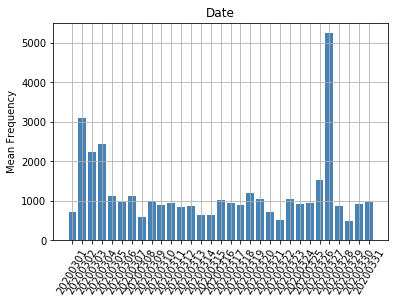

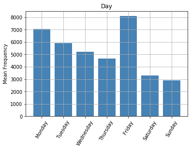

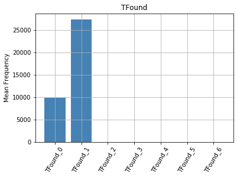

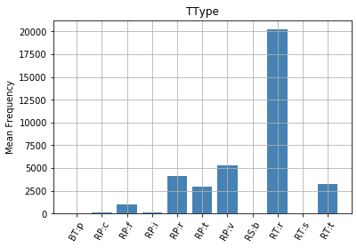

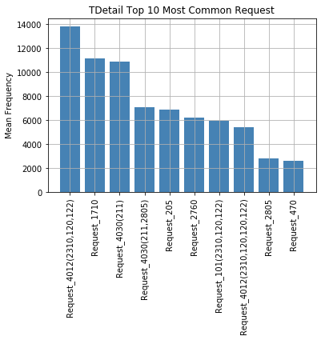

```python
i = 2
# For each category, plot bar graph for each group
for name in categories:
    if name != 'TDetail':
        plt.bar(categories[name],
                df_group.loc[i,categories[name]].values,
                color='steelblue')
        plt.xticks(rotation=60)
        plt.ylabel('Mean Frequency')
        plt.title(name)
        plt.grid(True)
        plt.show()
    else:
        row = df_group.loc[i,categories[name]]
        row = row.sort_values(ascending=False)
        plt.bar(row.index[0:10],row.values[0:10],color='steelblue')
        plt.title(name + str(' Top 10 Most Common Request'))
        plt.xticks(rotation=90)
        plt.ylabel('Mean Frequency')
        plt.grid(True)
        plt.show()
```

## Conclusion

We've analyzed the vendor log for March 2020 from both overall and customer-wise perspectives. The basic statistics on the overall data set showed that there are some periodic patterns in the transaction requests and that the majority of the transactions are requested by a few major customers. Next, we grouped the data by CustID and studied the behavior of the top three customers. Finally, we conducted two unsupervised machine learning algorithms to attempt to cluster the customers into groups. The machine learning models indicataed that there are three groups, which we later found had distinctive behavioral characteristics. Although we succeeded in clustering the customers into groups, it should be noted that each customer has unique behavioral tendencies and hence the traits of each cluster do not always represent all the members of the group accurately.